# Week 3: RAG and Agentic RAG

Applied Generative AI for AI Developers

Amit Arora

## Agenda

- Why RAG: training cutoffs, private data, and hallucinations
- RAG in one pipeline: embed, index, retrieve, generate
- Embeddings and vector databases
- Chunking: naive, contextual, late
- Hybrid search, query rewriting, reranking
- Lab: build a RAG pipeline
- Next week: Advanced RAG – evaluation with RAGAS, SQL and Graph RAG, agentic RAG

# The Problem: What an LLM Cannot Know

## Frozen in Time

An LLM’s knowledge stops at its **training cutoff**. Everything it will ever “know” was fixed the day training ended.

[figure not shown]

Two kinds of questions live outside that region: **your data** (laptop files, company wiki, sales database – never in any training set) and **anything after the cutoff** (this morning’s outage, yesterday’s earnings call). Answering them from nothing is a **hallucination**.

Models from two or three years ago really would answer these questions with confident fiction. Almost any LLM today tells you it does not have the information. Hallucination is not solved, though – it moved to subtler places: plausible-but-wrong details, misattributed quotes, invented citations.

## How We Used to Fight Hallucinations

In the earliest days of GenAI, the main defense was to beg, right in the prompt. Every production prompt carried a line like one of these:

```
Answer ONLY from the context provided. If the answer is not in the
context, say "I don't know."
```

```
If you are not sure, respond with "I do not have enough information
to answer this question." Do NOT make up an answer.
```

```
Never guess. If the documents below do not contain the answer,
reply exactly: I don't know.
```

That was the state of the art – instructions were the only tool anyone had. Today’s models are trained to decline when they lack grounding, so the begging does much less work. A line like this still helps at the margin, and it costs a dozen tokens – but as you will see in the lab, it may no longer be mandatory.

## The Fix: Bring Your Own Context

- The model cannot know your data, but it is excellent at **reading**
- So at question time, we fetch the relevant information and put it **into the prompt** – we call that added information **context**
- The generic recipe:
  1. **Retrieve** data relevant to the question
  2. **Augment** the prompt with it
  3. **Generate** the answer from it
- That recipe is **Retrieval Augmented Generation (RAG)** – and because the model now quotes sources instead of reciting memory, you get **attribution** for free

## Context Comes in Three Shapes

[output not shown]

Today is mostly the first row – it is where RAG started and where most production systems live. But keep all three in mind: the best systems pick the right shape per question.

## What is RAG?

RAG = Retrieval Augmented Generation A generative AI approach where the model combines external knowledge retrieval with text generation to provide more accurate and contextually rich responses.

## Simple RAG Architecture

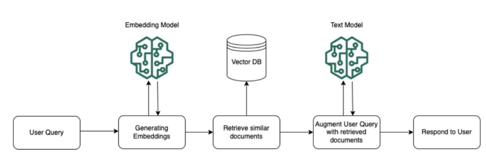

Key Components:

- **Document Processing**: Converts raw documents into chunks and creates embeddings for efficient retrieval.
- **Vector Storage**: Stores document embeddings and enables similarity search.
- **Query Processing**: Converts user questions into embeddings and finds relevant documents.
- **Response Generation**: Combines retrieved context with LLM capabilities to generate accurate answers.

## RAG: 100 to 300

**100 level**

Before the model answers, look up the relevant documents and paste them into the prompt. The model reads them and answers from what it read, citing sources.

**200 level**

Embed every chunk of your corpus once; embed the query at ask time; nearest-neighbor search returns the top-k chunks; they go into the prompt as context. An approximate index (HNSW) keeps search fast at millions of chunks – HNSW and friends are explained later in this deck, with vector databases.

**300 level**

Production RAG layers on: hybrid lexical+semantic search, rerankers, query rewriting, contextual chunking, and metadata filters – then measures itself with retrieval and generation metrics (RAGAS). Each layer exists because a failure mode demanded it; the rest of today walks them.

# Embeddings: The Foundation of Semantic Retrieval

## What are Vector Embeddings?

- **Definition**: Numerical representations of text, images, or other data
- **Purpose**: Capture semantic meaning in vector space
- **Applications**: Search, recommendations, classification, RAG retrieval

### Representation Learning

- **Semantic Similarity**: Similar concepts have similar vectors
- **Vector Space**: High-dimensional representations (typically 384-3072 dimensions)
- **Distance Metrics**: Cosine similarity, Euclidean distance, dot product

## Example: Retrieval By Hand

Four tiny “documents,” each embedded to just 2 numbers so we can compute everything ourselves. The query gets embedded by the same model.

[figure not shown]

The query lands next to the documents that share its meaning – no keyword overlap required (“cab prices” matches “taxi fares”).

## Choosing an Embedding Model

Key Considerations:

- **Model selection**: Weigh accuracy, speed, cost, and dimension count.
- **Dimensions**: More dimensions capture more meaning and cost more to store and search.
- **Languages**: For multilingual corpora, pick a multilingual model (Cohere multilingual, Qwen3-Embedding).
- **Domains**: Medical and legal text often needs a fine-tuned model – see [Sentence Transformers](https://huggingface.co/blog/train-sentence-transformers).

## Getting Embeddings: Self-Host or Call an API

Whatever model you pick, there are exactly two ways to consume it:

### Self-host

You run the model; text never leaves your infrastructure.

- **Ollama** – what we did in the Week 2 lab: `ollama pull nomic-embed-text`, then POST to `/api/embed`
- **vLLM** – production-grade: `vllm serve BAAI/bge-large-en-v1.5 --task embed`
- **SGLang** – launch with `--is-embedding`
- vLLM and SGLang both expose the OpenAI-compatible `/v1/embeddings` endpoint, so client code stays portable

### Call an API

You send text, they send back vectors; you host nothing.

- OpenAI (`text-embedding-3`), Cohere, Voyage AI, Gemini
- Pay per token; zero ops
- Your text goes to the provider – a real consideration for sensitive corpora
- Latency and rate limits are theirs, not yours

The trade is the same one as LLM serving in Week 2: control and privacy vs. zero operations.

## Popular Embeddings Models

- **nomic-embed-text**: What you already ran in the Week 2 lab – 768 dimensions, 260 MB, runs locally via Ollama. Our course workhorse.
- **Hugging Face**: Huge collection of open embedding models (check the [MTEB leaderboard](https://huggingface.co/spaces/mteb/leaderboard)), e.g. [BGE-large-en-v1.5](https://huggingface.co/BAAI/bge-large-en-v1.5), Sentence Transformers (SBERT, MPNet)
- **OpenAI embeddings**: text-embedding-3-small/large; excellent general-purpose performance but can be expensive for large-scale applications.
- **Cohere embeddings**: Strong multilingual support and competitive performance.
- **Qwen3-Embedding / Gemini embedding**: Current leaders on the MTEB leaderboard – open-weight and hosted respectively.
- **Voyage AI**: Recommended by Anthropic, state-of-the-art performance with domain-specific models for finance, healthcare, and code.
- **ColBERTv2**: Late interaction model – independently encodes queries and documents, then uses “MaxSim” for fine-grained token-level similarity. [Paper](https://arxiv.org/pdf/2112.01488), [HuggingFace](https://huggingface.co/colbert-ir/colbertv2.0), [LangChain example](https://python.langchain.com/docs/integrations/retrievers/ragatouille/).

## Fine-tuning Embedding Models

### Why Fine-tune?

- **Domain Adaptation**: Specific vocabulary and concepts (medical, legal, financial)
- **Improved Accuracy**: Task-specific retrieval performance
- **Custom Requirements**: Unique business needs
- **How**: Contrastive training on (query, relevant passage) pairs with [Sentence Transformers](https://huggingface.co/blog/train-sentence-transformers)

# Building RAG Pipelines

## Building a Basic RAG App

[figure not shown]

Six steps, two pipelines: **prepare** and chunk documents, **embed** the chunks, **store** them in a vector database (ingestion, once) – then **embed** the user’s question with the same model, **retrieve** the nearest chunks, and **generate** the answer from them (query, every request).

The pipeline works, end to end. **What is missing?**

## What Is Missing: Evaluation

### How do we know the answers are grounded in the context we provide?

And one step earlier: how do we know retrieval found the right documents at all? A RAG pipeline without measurement is a demo, not a system.

We measure both – retrieval quality and generation quality. The metrics and tooling (RAGAS) open next week’s lecture, and evaluation gets a full week of its own (Week 7).

## Chunking Strategies

> Reference: [Chunking techniques with LangChain and LlamaIndex](https://blog.lancedb.com/chunking-techniques-with-langchain-and-llamaindex/)
- **Document segmentation approaches**: Choose between fixed-size chunks, semantic chunking, or paragraph-based splitting depending on your content structure.
- **Chunk size considerations**: Balance between too large (dilutes relevance) and too small (loses context) - typically 256-1024 tokens works well.
- **Overlap between chunks**: Include some overlap (10-20%) between consecutive chunks to maintain context across boundaries.
- **Maintaining context**: Preserve important metadata and hierarchical information when splitting documents.
- **Structured vs unstructured data**: Adapt chunking strategy based on whether you’re dealing with free text, tables, or structured documents.

## The Problem with Naive Chunking

Traditional RAG splits documents and embeds each chunk on its own. Context gets lost:

```
Original document:
"Acme Corp revenue grew 15% in Q3. The company attributed
this growth to their new AI product line launched in Q2."

Chunk 2 (after splitting):
"The company attributed this growth to their new AI product line
launched in Q2."
```

**Problem**: Which company? What growth? The chunk is orphaned from its context.

## Contextual Retrieval: The Solution

Anthropic’s approach: use Claude to **prepend chunk-specific context** to each chunk before embedding.

```
Contextual Chunk 2:
"This chunk is from Acme Corp's Q3 earnings report. It discusses
revenue growth of 15%. The company attributed this growth to
their new AI product line launched in Q2."
```

### Results

- **49% reduction** in failed retrievals with contextual embeddings alone
- **67% reduction** when combined with reranking
- Uses **prompt caching** to keep costs manageable (pennies per document)

### Key Insight

For knowledge bases under **200K tokens**, you may not need RAG at all – just put the entire context in the prompt window.

Source: [Anthropic Blog - Contextual Retrieval](https://www.anthropic.com/news/contextual-retrieval)

## Why One Retriever Is Not Enough

Two queries, two failure modes:

### “error E4021 in billing”

Embeddings blur exact tokens – E4021 and E4012 land nearly on top of each other in vector space. Keyword search finds the literal string every time.

**Exact words win**: product IDs, error codes, names, legal citations.

### “car won’t start”

The manual says “vehicle ignition failure” – zero words in common, same meaning. Keyword search returns nothing. Embeddings match it easily.

**Meaning wins**: synonyms, paraphrase, cross-language.

Production RAG runs **both** and merges the results. That is hybrid search – the next three slides.

## BM25: Keyword Search, Done Properly

**BM25 = “Best Matching 25”** – a ranking algorithm, the 25th iteration of the scoring function from the Okapi retrieval system (Robertson et al., 1990s). It is the lexical scorer inside Elasticsearch, OpenSearch, and every Lucene descendant. For each query term in a document, it multiplies three signals:

- **Rarity (IDF)**: “E4021” appearing in 3 documents out of a million tells you a lot; “the” tells you nothing
- **Term frequency, with saturation**: a document that mentions “taxi” five times beats one that mentions it once – but the fiftieth mention adds almost nothing
- **Length normalization**: a term hit in a 100-word memo counts for more than the same hit buried in a 100-page manual

Sum over the query terms and you have the document’s score. No training, no vectors, no GPU – it has run the world’s search boxes since the 1990s, and it is still the strongest baseline in retrieval benchmarks.

**IDF, inverse document frequency**: count how many of your $N$ documents contain a term ($df$), then invert it: $idf(t) \approx \log(N/df)$. A term in every document scores near zero; a term in 3 documents out of a million scores high. Computed once at index time, it is how a search engine knows “E4021” matters and “the” does not.

## Reciprocal Rank Fusion: Merging Two Rankings

Each retriever sorts **its own** results: rank 1 is its best match, rank 2 the next best, and so on. The scores behind those ranks (BM25 points, cosine similarity) live on different scales and cannot be compared – but a rank is just a rank.

[figure not shown]

RRF fuses the two rankings in two moves: convert every rank to points with $\frac{1}{60 + rank}$, then add up each document’s points across both lists.

[figure not shown]

## Hybrid Search: The Full Pipeline

[figure not shown]

- The **reranker** is a cross-encoder: it reads query and document together, scoring relevance far better than either retriever – too slow for millions of documents, perfect for a merged shortlist of 50
- Starting weights when your stack supports weighting: 30% BM25 / 70% vector; tune on your own queries

Source: [Superlinked - Optimizing RAG with Hybrid Search](https://superlinked.com/vectorhub/articles/optimizing-rag-with-hybrid-search-reranking)

## Query Rewriting

Retrieval quality depends as much on the **query** as on the index.

- **Query expansion**: Add synonyms and related terms before searching
- **Query decomposition**: Split complex questions into simpler sub-queries
- **HyDE (Hypothetical Document Embeddings)**: Ask the LLM to write a hypothetical answer, then embed *that* for retrieval – documents match documents better than questions match documents
- **Conversational rewriting**: Resolve pronouns and references from chat history (“what about its pricing?” -> “what is Pinecone’s pricing?”)
- **Entity extraction**: Pull out names, IDs, and filters to combine vector search with metadata filtering

# Vector Databases

## Why a Vector Database at All?

- Retrieval means: given a query vector, find the closest vectors among **millions**
- Brute force computes the similarity against every stored vector, per query – fine at 10,000 chunks, hopeless at 50 million with users waiting
- **Approximate Nearest Neighbor (ANN)** search is the escape: give up a tiny bit of recall (find *almost always* the true neighbors) for orders-of-magnitude speed
- A vector database packages the pieces you would otherwise build yourself:
  - An ANN index (HNSW is the workhorse – next slide)
  - Metadata filtering (“only documents from 2026”, “only this tenant”)
  - The database parts: persistence, updates, replication, access control

## HNSW: How ANN Search Actually Works

**Hierarchical Navigable Small World** – the index behind most vector databases (Pinecone, Qdrant, Weaviate, pgvector, OpenSearch).

[figure not shown]

- **The idea**: a highway system for vectors. Sparse top layers make long hops toward the right region; each lower layer is denser and refines the position; layer 0 holds every vector
- **300-level notes**: greedy best-first search per layer; build-time parameter M (links per node) and ef (search width) trade recall against speed and memory; alternatives include IVF (cluster-then-probe) and product quantization (compress vectors), often combined at billion scale

## Vector Databases

Features to Consider:

- **Scale**: Handles millions to billions of vectors.
- **Query speed**: ANN search answers in milliseconds at scale.
- **Search options**: Distance metrics (cosine, euclidean, dot product) and index types.
- **Metadata filtering**: Combines similarity search with filters (date, tenant, source).
- **Cost**: Hosting, per-query, and storage costs pull in different directions.

## Examples of Vector Databases

- **Pinecone**: Managed service; you never run a server. Strong choice when you want zero ops.
- **turbopuffer**: Serverless search on object storage – vectors and full-text in one engine, priced by what you store and query. Powers search in Cursor and Notion.
- **Weaviate**: Open source, hybrid search (text + vector) built in, optional managed cloud.
- **Milvus**: Open source, built for billion-vector deployments; the heavyweight of the group.

## Examples of Vector Databases (contd.)

- **Qdrant**: Open source, rich filtering and hybrid search; runs from laptop to production. **Our lab uses it embedded** – a Python package writing to a local folder, no server.
- **OpenSearch**: Full-text search platform with k-NN vectors added; one engine for text, vectors, and metadata.
- **FAISS (Meta)**: A library, not a database – in-memory, fast, no persistence or filtering. Great for labs and prototypes.
- **Chroma**: Small, embeddable store; two lines of Python to first query.
- **PostgreSQL + pgvector**: Vectors inside the database you already run – often the right answer for teams on Postgres.

## Lab: Build a RAG Pipeline

### Hands-on Exercise – same models as the Week 2 lab, everything local

- **No API keys, no cloud calls**: **nomic-embed-text** for embeddings and **MiniCPM5-2B** for generation, both through Ollama – the same two models you already pulled
- Vectors live in **Qdrant**, a real vector database running as an embedded Python package: no server, no Docker, just a `qdrant_db/` folder next to your code
- Build the full pipeline: load, chunk, embed, index, retrieve, answer – about a corpus no model could know from training
- Then **break it**: make the model hallucinate on purpose, watch it happen
- Then **fix it**: metadata filtering and query rewriting – today’s techniques, applied

## References & Further Reading

### Retrieval Approaches

1. [Anthropic Engineering: Claude Code Best Practices (Agentic Search)](https://www.anthropic.com/engineering/claude-code-best-practices)
2. [Latent Space Podcast: Claude Code](https://www.latent.space/p/claude-code) – Cat Wu and Boris Cherny on grep vs embeddings
3. [Anthropic Blog: Contextual Retrieval](https://www.anthropic.com/news/contextual-retrieval)
4. [Superlinked: Optimizing RAG with Hybrid Search & Reranking](https://superlinked.com/vectorhub/articles/optimizing-rag-with-hybrid-search-reranking)
5. [Chunking Techniques with LangChain and LlamaIndex](https://blog.lancedb.com/chunking-techniques-with-langchain-and-llamaindex/)

### Embeddings

1. [MTEB Leaderboard](https://huggingface.co/spaces/mteb/leaderboard)
2. [Training Sentence Transformers](https://huggingface.co/blog/train-sentence-transformers)
3. [OpenAI Embeddings Guide](https://platform.openai.com/docs/guides/embeddings)

### Agents

1. [Anthropic: Building Effective Agents](https://www.anthropic.com/engineering/building-effective-agents)
2. [Model Context Protocol](https://modelcontextprotocol.io/)
3. [Anthropic Tool Use Documentation](https://docs.anthropic.com/en/docs/build-with-claude/tool-use)

### RAG Evaluation & AWS

1. [RAGAS Documentation](https://docs.ragas.io/en/stable/) and [Paper (arXiv:2309.15217)](https://arxiv.org/abs/2309.15217)
2. [Amazon Bedrock Knowledge Bases](https://aws.amazon.com/bedrock/knowledge-bases/)
3. [Amazon Bedrock Knowledge Bases Documentation](https://docs.aws.amazon.com/bedrock/latest/userguide/knowledge-base.html)

### Course Resources

1. [Course Bookmarks: RAG](https://github.com/gu-dsan6725/bookmarks/tree/main?tab=readme-ov-file#rag)